# Modeling and prediction for movies

## Setup

### Load packages

```r
library(ggplot2)
library(dplyr)
library(statsr)
library(GGally)
library(gmodels)
library(SignifReg)
library(magrittr)
```

### Load data

```r
load("movies.Rdata")
```

## Part 1: Data

Generalizability : The data set is comprised of 651 randomly sampled movies produced and released before 2016. So it has generalizability.

Causality : In the data set, Each variable does not affect or depend on to the others. Therefore, There is no causality in the data.

## Part 2: Research question

Question : Is the audience score predictable with other variables?

Motivation : There are many variables in this data. Using this variables, I want to know a linear association with audience score and if there is the association, I want to make a model to predict the audience score of new data.

## Part 3: Exploratory data analysis

I deleted character variables such as title, dircetor etc. Because These variabels can’t calculate or summarize as categorial or continuous variable.

```r
raw<-movies

raw%<>%select(-c(1:12),-c(imdb_num_votes,director,actor1,actor2,actor3,actor4,actor5,imdb_url,rt_url))

summary(raw)
```

```
##   imdb_rating            critics_rating critics_score    audience_rating
##  Min.   :1.900   Certified Fresh:135    Min.   :  1.00   Spilled:275
##  1st Qu.:5.900   Fresh          :209    1st Qu.: 33.00   Upright:376
##  Median :6.600   Rotten         :307    Median : 61.00
##  Mean   :6.493                          Mean   : 57.69
##  3rd Qu.:7.300                          3rd Qu.: 83.00
##  Max.   :9.000                          Max.   :100.00
##  audience_score  best_pic_nom best_pic_win best_actor_win best_actress_win
##  Min.   :11.00   no :629      no :644      no :558        no :579
##  1st Qu.:46.00   yes: 22      yes:  7      yes: 93        yes: 72
##  Median :65.00
##  Mean   :62.36
##  3rd Qu.:80.00
##  Max.   :97.00
##  best_dir_win top200_box
##  no :608      no :636
##  yes: 43      yes: 15
##
##
##
##
```

To figure out the association, I used scatter plot function. The resource variables are ‘audience_score’,‘imdb_rating’ and ‘critics_score’

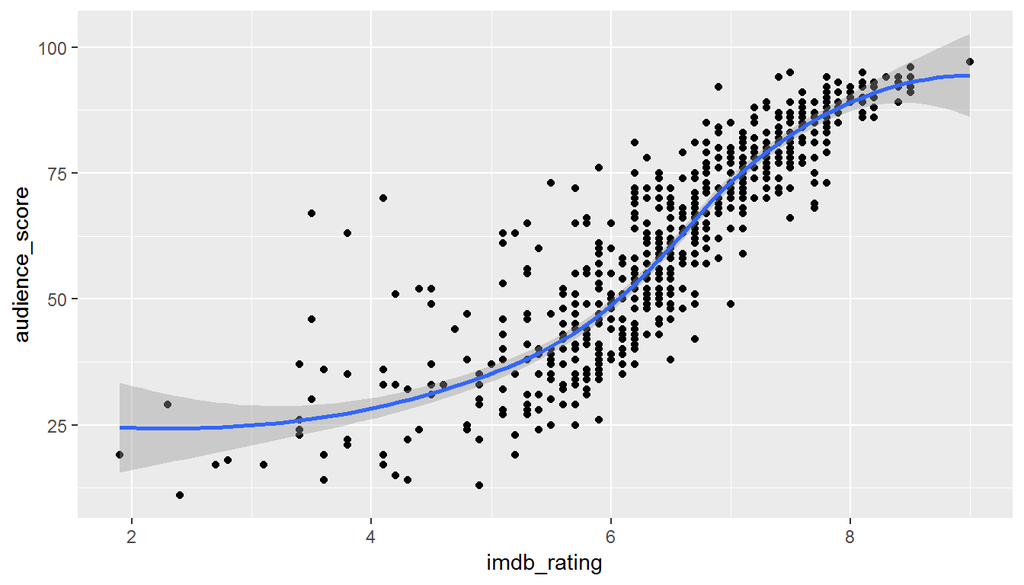

```r
ggplot(raw,aes(x=imdb_rating,y=audience_score))+geom_point()+geom_smooth()
```

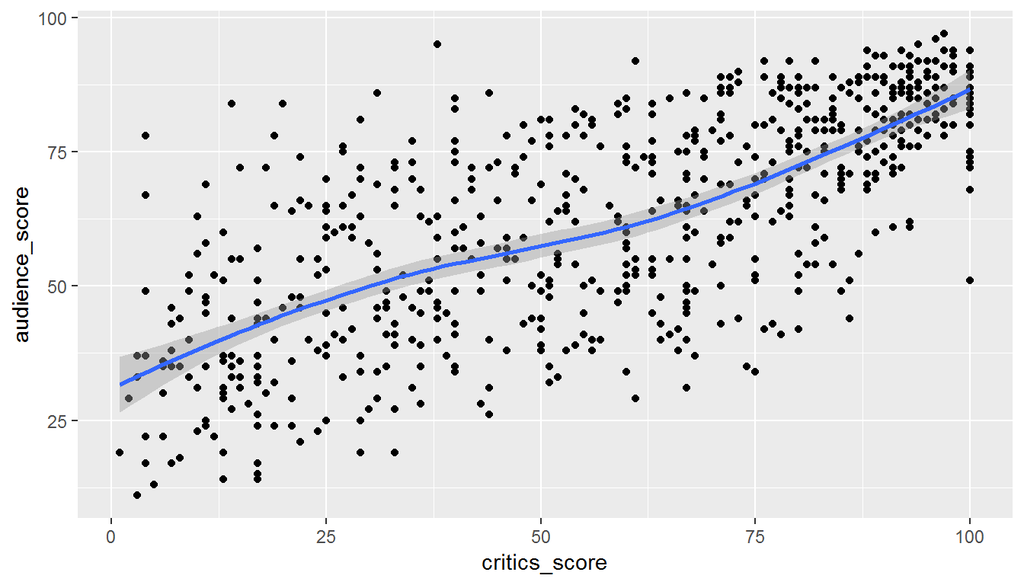

```r
ggplot(raw,aes(x=critics_score,y=audience_score))+geom_point()+geom_smooth()
```

Above plot charts have a positive direction. Especially, the second chart(i.e the plot chart that the variables are ciritics_score and audience_score.) has a almost linear association between explanatory and response variable.

To figure out another variables to affect audience score, I plotted boxplot that the x axis are categorial variables and y axis is audience_score.

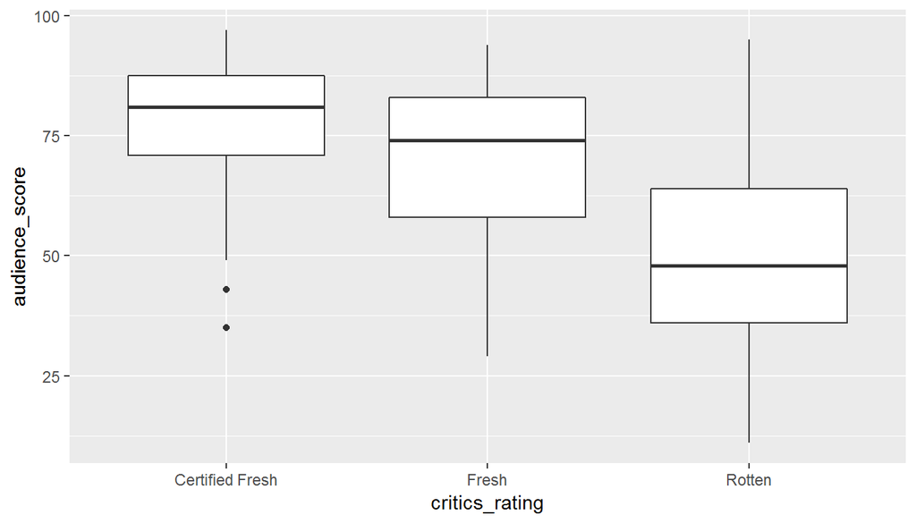

```r
ggplot(raw,aes(x=critics_rating,y=audience_score))+geom_boxplot()
```

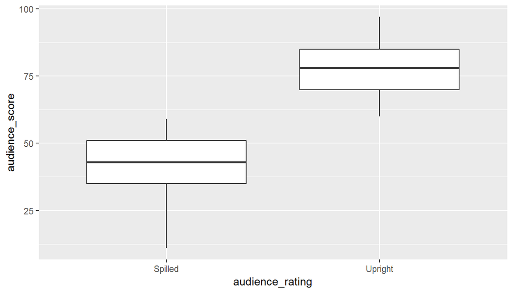

```r
ggplot(raw,aes(x=audience_rating,y=audience_score))+geom_boxplot()
```

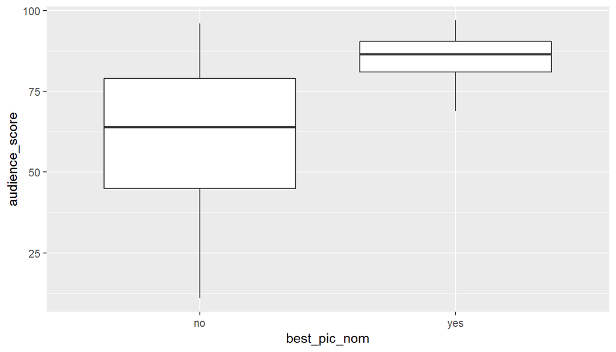

```r
ggplot(raw,aes(x=best_pic_nom,y=audience_score))+geom_boxplot()
```

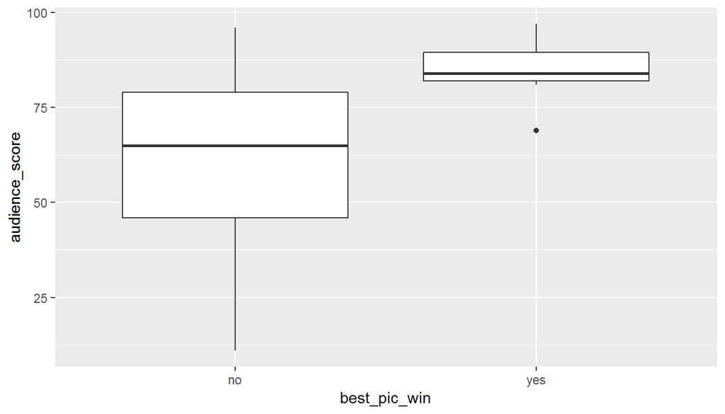

```r
ggplot(raw,aes(x=best_pic_win,y=audience_score))+geom_boxplot()
```

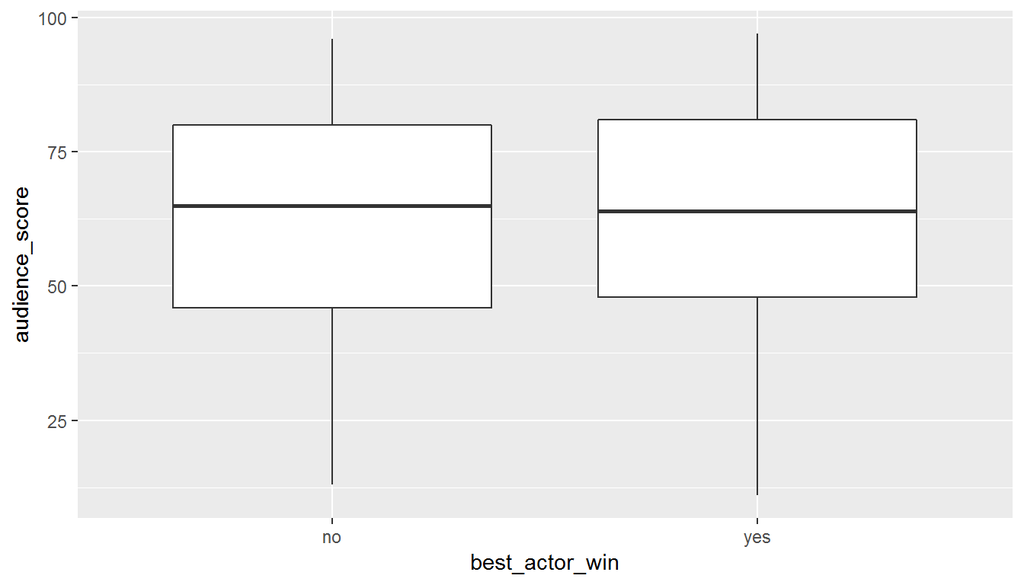

```r
ggplot(raw,aes(x=best_actor_win,y=audience_score))+geom_boxplot()
```

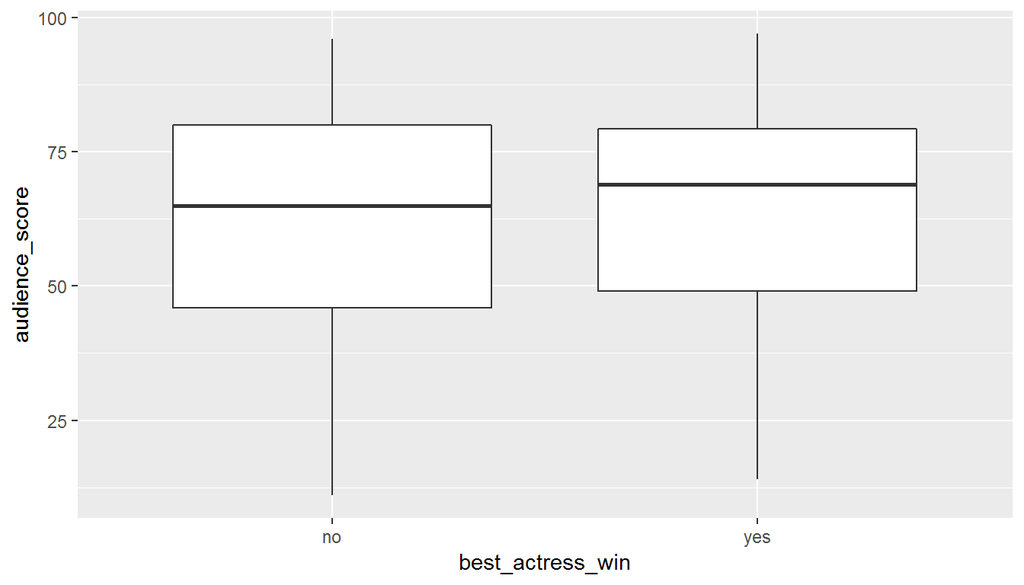

```r
ggplot(raw,aes(x=best_actress_win,y=audience_score))+geom_boxplot()
```

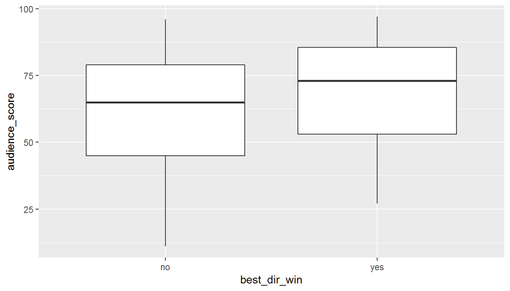

```r
ggplot(raw,aes(x=best_dir_win,y=audience_score))+geom_boxplot()
```

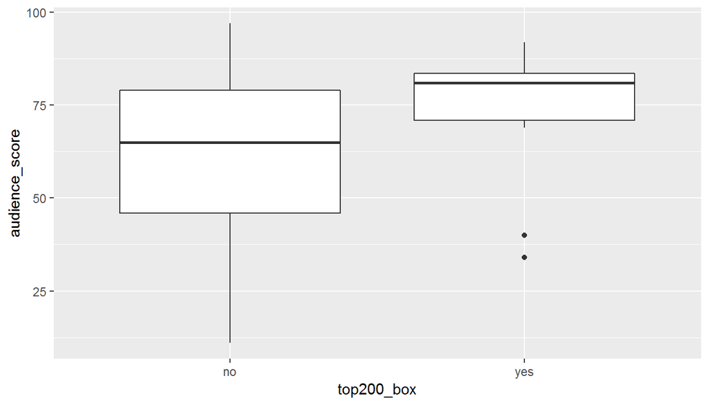

```r
ggplot(raw,aes(x=top200_box,y=audience_score))+geom_boxplot()
```

Therefore, there is possible to predict audience score using a linear regression model. Thus, I will make a model in part 4.

## Part 4: Modeling

In part3, I checked that the linear model is possible to solve my reserch question. I will make multiple linear regression model to predict audience score

```r
model<-lm(audience_score~.,data = raw)

summary(model)
```

```
##
## Call:
## lm(formula = audience_score ~ ., data = raw)
##
## Residuals:
##      Min       1Q   Median       3Q      Max
## -22.1134  -4.7633   0.6386   4.2856  24.1151
##
## Coefficients:
##                        Estimate Std. Error t value Pr(>|t|)
## (Intercept)            -8.68096    2.66515  -3.257  0.00118 **
## imdb_rating             9.09448    0.45259  20.094  < 2e-16 ***
## critics_ratingFresh    -0.29852    0.82281  -0.363  0.71687
## critics_ratingRotten   -0.83777    1.35809  -0.617  0.53754
## critics_score           0.01384    0.02459   0.563  0.57376
## audience_ratingUpright 20.51759    0.78328  26.195  < 2e-16 ***
## best_pic_nomyes         3.43406    1.79293   1.915  0.05590 .
## best_pic_winyes        -2.00282    3.16841  -0.632  0.52753
## best_actor_winyes      -0.47091    0.80203  -0.587  0.55731
## best_actress_winyes    -1.68076    0.89760  -1.873  0.06159 .
## best_dir_winyes        -0.07725    1.17722  -0.066  0.94770
## top200_boxyes          -0.08041    1.85019  -0.043  0.96535
## ---
## Signif. codes:  0 '***' 0.001 '**' 0.01 '*' 0.05 '.' 0.1 ' ' 1
##
## Residual standard error: 6.946 on 639 degrees of freedom
## Multiple R-squared:  0.884,  Adjusted R-squared:  0.882
## F-statistic: 442.8 on 11 and 639 DF,  p-value: < 2.2e-16
```

To select model, I used backward elimination with p-value since it requires fitting fewer models.

```r
fit<-SignifReg(audience_score~.,data = raw,direction="backward",criterion = "p-value")
summary(fit)
```

```
##
## Call:
## lm(formula = reg, data = data)
##
## Residuals:
##      Min       1Q   Median       3Q      Max
## -22.1570  -4.7630   0.6209   4.3572  24.3224
##
## Coefficients:
##                        Estimate Std. Error t value Pr(>|t|)
## (Intercept)            -11.4864     2.0068  -5.724 1.59e-08 ***
## imdb_rating              9.5191     0.3497  27.220  < 2e-16 ***
## audience_ratingUpright  20.8473     0.7674  27.166  < 2e-16 ***
## ---
## Signif. codes:  0 '***' 0.001 '**' 0.01 '*' 0.05 '.' 0.1 ' ' 1
##
## Residual standard error: 6.952 on 648 degrees of freedom
## Multiple R-squared:  0.8822, Adjusted R-squared:  0.8818
## F-statistic:  2426 on 2 and 648 DF,  p-value: < 2.2e-16
```

I used SignifReg function to conduct backward elimination with p-value. the explanatory variables of the ‘fit’ model are ‘imdb_rating’ and ‘audience_rating-Upright’.

Model dignostics

linear relationship between (numerical)X and y

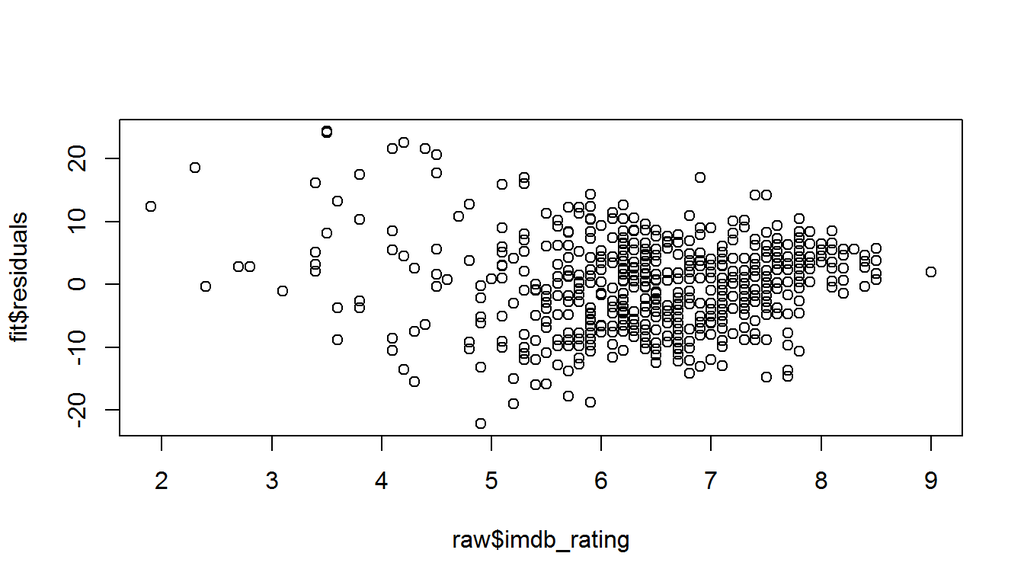

```r
plot(fit$residuals~raw$imdb_rating)
```

The scatterplot randomly fall around 0. Thus, linear relationship is correct.

Nearly normal residuals

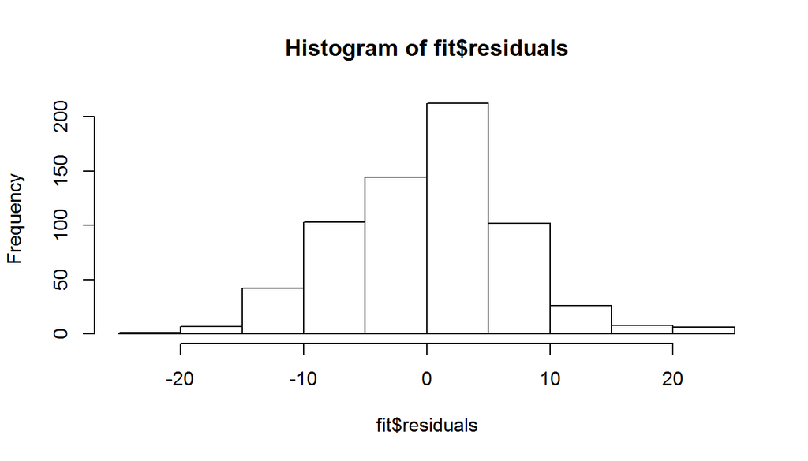

```r
hist(fit$residuals)
```

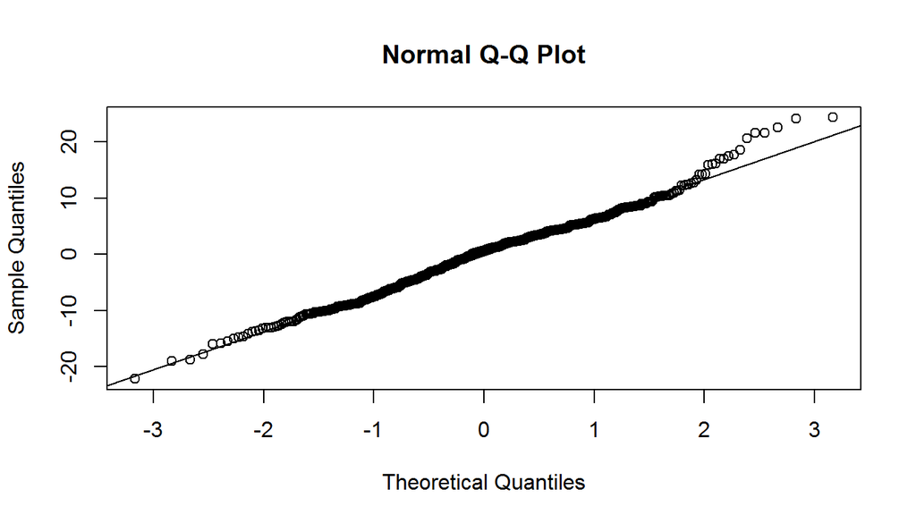

```r
qqnorm(fit$residuals)

qqline(fit$residuals)
```

The histogram of residuals shows the residuals centered at 0. Also, The normal probability plot shows residuals centerd at 0.

constant variability of residuals

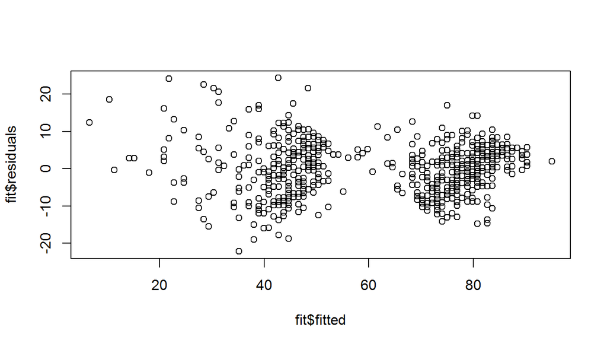

```r
plot(fit$residuals ~fit$fitted)
```

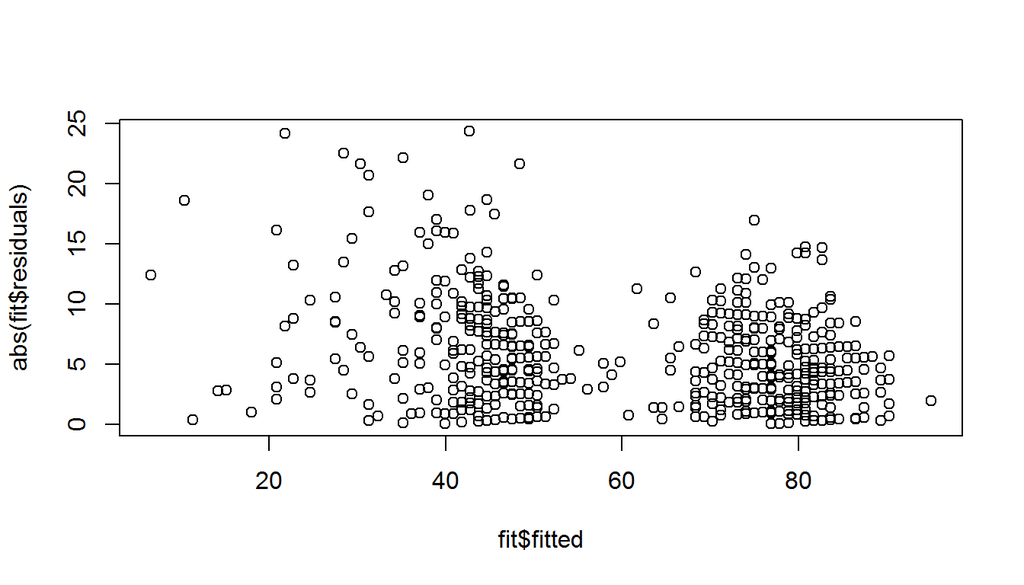

```r
plot(abs(fit$residuals) ~fit$fitted)
```

Above two plots, there are no fan shape and scattered around 0.

Independent residuals

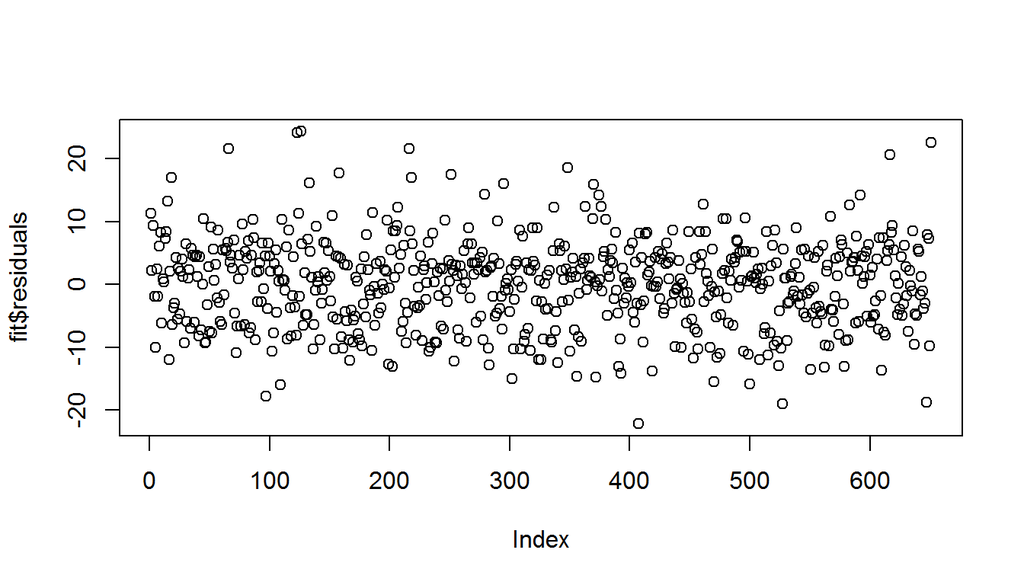

```r
plot(fit$residuals)
```

There is no pattern and not time series data. Therefore, the observations are independent.

Interpretation of model coefficients

```r
summary(fit)
```

```
##
## Call:
## lm(formula = reg, data = data)
##
## Residuals:
##      Min       1Q   Median       3Q      Max
## -22.1570  -4.7630   0.6209   4.3572  24.3224
##
## Coefficients:
##                        Estimate Std. Error t value Pr(>|t|)
## (Intercept)            -11.4864     2.0068  -5.724 1.59e-08 ***
## imdb_rating              9.5191     0.3497  27.220  < 2e-16 ***
## audience_ratingUpright  20.8473     0.7674  27.166  < 2e-16 ***
## ---
## Signif. codes:  0 '***' 0.001 '**' 0.01 '*' 0.05 '.' 0.1 ' ' 1
##
## Residual standard error: 6.952 on 648 degrees of freedom
## Multiple R-squared:  0.8822, Adjusted R-squared:  0.8818
## F-statistic:  2426 on 2 and 648 DF,  p-value: < 2.2e-16
```

Slope of imdb_rating : All else held constant, for each 1 point increase in volume the model predicts the audience score to be higher on average by 9.5191 point.

Slope of audience_rating(Upright) : All else held constant, the model predicts that audience_rating that answered ‘Upright’ 20.8473 point higher than answered ‘Spilled’,on average.

## Part 5: Prediction

Predict data Hacksaw ridge’s imdb_rating is 8.2 and audience_rating is “Upright” The orginal audience score of the movie on Rotten Tomatoes is 91 point.

La La Land’s imdb_rating is 8.1 and audience_rating is “Upright” The orginal audience score of the movie on Rotten Tomatoes is 81 point.

Dangal’s imdb_rating is 8.5 and audience_rating is “Upright” The orginal audience score of the movie on Rotten Tomatoes is 94 point.

Link of Hacksaw Ridge

Rotten Tomateos

https://www.rottentomatoes.com/m/hacksaw_ridge#audience_reviews

IMDB

https://www.imdb.com/title/tt2119532/?pf_rd_m=A2FGELUUNOQJNL&pf_rd_p=e31d89dd-322d-4646-8962-327b42fe94b1&pf_rd_r=EDWKHQ1ZXNFPGYPZV9B0&pf_rd_s=center-1&pf_rd_t=15506&pf_rd_i=top&ref_=chttp_tt_175

Link of La La Land

Rotten Tomatoes

https://www.rottentomatoes.com/m/la_la_land

IMDB

https://www.imdb.com/title/tt3783958/?ref_=nv_sr_1

Link of dangal

Rotten Tomatoes

IMDB

https://www.rottentomatoes.com/m/dangal

```r
new<-data.frame(imdb_rating=c(8.2,8.1,8.5),audience_rating=c("Upright","Upright","Upright"))

predict_value<-predict(fit,new)#prediction score using model

original_value<-c(91,81,94)#Original audience score

diff_value<-original_value-predict_value
#Difference between original score and prediction score

sum(diff_value^2)/3#calculate MSE
```

```
## [1] 18.8657
```

The mean square error is 18.8657 points.

Confidence interval for coefficient

```r
confint(fit,"imdb_rating",level = 0.95)
```

```
##               2.5 %   97.5 %
## imdb_rating 8.83236 10.20575
```

```r
confint(fit,"audience_ratingUpright",level = 0.95)
```

```
##                           2.5 %   97.5 %
## audience_ratingUpright 19.34045 22.35421
```

Interpretation

imdb_rating We are 95% confident that, all else being equal, the model predicts that the audience score that incresing 1 point of imdb_raing is higher between 8.83236 and 10.20575 point,on avarage.

## Part 6: Conclusion

The fit model coefficients are imdb_rating and audience_rating and model adjust r-square point is about 0.88. There was no problem when diagnose the fitted model. Therefore, the audience score is possible to predict with fitted linear regression model.